# RNA-seq Analysis: HIF-2α Inhibition

Katsuhiro Ito

2026-09-23

# Overview

This R Markdown document contains the downstream RNA-seq analysis used for the study:

**Pharmacologic HIF-2α inhibition preserves T cell effector function in clear cell renal cell carcinoma**

RNA-seq data were generated from tumor-infiltrating lymphocytes (TILs) and peripheral blood mononuclear cells (PBMCs) following HIF-2α inhibitor treatment.

RSEM gene-level expression estimates were used for downstream analyses.

The RNA-seq alignment and quantification workflow is described separately in the repository README.

# Software

# Data input

The analysis uses RSEM gene-level result files (`rsem.genes.results`).

The input directory should contain the RSEM output files generated by the RNA-seq processing pipeline.

```r
data_dir <- "./Project_Knm32/"

files <- list.files(
  data_dir,
  pattern = "rsem.genes.results",
  recursive = TRUE,
  full.names = TRUE
)

tx.rsem <- tximport(
  files,
  type = "rsem",
  txIn = FALSE,
  txOut = FALSE
)

# Extract sample names from the relative file paths.
file_relative <- list.files(
  data_dir,
  pattern = "rsem.genes.results",
  recursive = TRUE,
  full.names = FALSE
)

name <- str_split(file_relative, pattern = "\\/", simplify = TRUE)[, 1]
name <- str_remove(name, pattern = "Sample_")

message("Sample name list")
print(name)
```

```
##  [1] "HD_36_Belzutifan_127_066"    "HD_36_DMSO_187_006"
##  [3] "HD_38_Belzutifan_115_078"    "HD_38_DMSO_175_018"
##  [5] "HD_44_Belzutifan_103_090"    "HD_44_DMSO_163_030"
##  [7] "HD_46_Belzutifan_186_007"    "HD_46_DMSO_151_042"
##  [9] "HD_48_Belzutifan_174_019"    "HD_48_DMSO_139_054"
## [11] "PBMC_158_Belzutifan_172_021" "PBMC_158_DMSO_162_031"
## [13] "PBMC_161_Belzutifan_160_033" "PBMC_161_DMSO_150_043"
## [15] "PBMC_169_Belzutifan_148_045" "PBMC_169_DMSO_138_055"
## [17] "PBMC_177_Belzutifan_136_057" "PBMC_177_DMSO_126_067"
## [19] "PBMC_181_Belzutifan_124_069" "PBMC_181_DMSO_114_079"
## [21] "PBMC_184_Belzutifan_112_081" "PBMC_184_DMSO_102_091"
## [23] "PBMC_189_Belzutifan_100_093" "PBMC_189_DMSO_184_009"
## [25] "TIL_158_Belzutifan_123_070"  "TIL_158_DMSO_183_010"
## [27] "TIL_169_Belzutifan_111_082"  "TIL_169_DMSO_171_022"
## [29] "TIL_177_Belzutifan_099_094"  "TIL_181_Belzutifan_182_011"
## [31] "TIL_181_DMSO_159_034"        "TIL_184_Belzutifan_170_023"
## [33] "TIL_184_DMSO_147_046"        "TIL_189_Belzutifan_158_035"
## [35] "TIL_189_DMSO_135_058"
```

# Sample annotation

Sample metadata were derived from the sample names.

Samples were classified according to:

- **organ:** TIL or PBMC
- **donor:** patient (PT) or healthy donor (HD)
- **treatment:** DMSO or Belzutifan (Bel)
- **patient ID:** derived from the sample name

```r
df <- tx.rsem$counts

coldata <- data.frame(
  organ = ifelse(str_detect(name, pattern = "TIL"), "TIL", "PBMC"),
  donor = ifelse(str_detect(name, pattern = "HD"), "HD", "PT"),
  tx = ifelse(str_detect(name, pattern = "Belzutifan"), "Bel", "DMSO"),
  id = paste(
    "pt",
    str_split(name, pattern = "_", simplify = TRUE)[, 2],
    sep = ""
  )
)

coldata$tx <- factor(
  coldata$tx,
  levels = c("DMSO", "Bel")
)

colnames(df) <- name
rownames(coldata) <- name

message("Completeness of samples")
table(coldata$id, coldata$tx, coldata$organ)
```

```
## , ,  = PBMC
##
##
##         DMSO Bel
##   pt158    1   1
##   pt161    1   1
##   pt169    1   1
##   pt177    1   1
##   pt181    1   1
##   pt184    1   1
##   pt189    1   1
##   pt36     1   1
##   pt38     1   1
##   pt44     1   1
##   pt46     1   1
##   pt48     1   1
##
## , ,  = TIL
##
##
##         DMSO Bel
##   pt158    1   1
##   pt161    0   0
##   pt169    1   1
##   pt177    0   1
##   pt181    1   1
##   pt184    1   1
##   pt189    1   1
##   pt36     0   0
##   pt38     0   0
##   pt44     0   0
##   pt46     0   0
##   pt48     0   0
```

# Differential expression analysis

Differential expression analysis was performed using `DESeq2`.

For paired analyses, patient ID was included in the design formula:

```
~ id + tx
```

For unpaired analyses, treatment was modeled without patient ID:

```
~ tx
```

RSEM expected counts were rounded to integers before construction of the `DESeqDataSet`.

The following function performs the differential expression analysis for a specified donor group and tissue type.

```r
deseq.custom <- function(
  df,
  coldata,
  donor = "PT",
  organ = "TIL",
  des = formula(~ id + tx)
) {

  df.comparison <- df[
    ,
    coldata$donor %in% donor &
      coldata$organ %in% organ,
    drop = FALSE
  ]

  coldata.comparison <- coldata[
    coldata$donor %in% donor &
      coldata$organ %in% organ,
    ,
    drop = FALSE
  ]

  dds <- DESeqDataSetFromMatrix(
    countData = round(df.comparison),
    colData = coldata.comparison,
    design = ~ id + tx
  )

  design(dds) <- des
  dds <- DESeq(dds)

  res <- results(dds)

  res.df <- data.frame(res)
  res.df$gene <- rownames(res.df)

  gene_info_Ensdb <- AnnotationDbi::select(
    EnsDb.Hsapiens.v86,
    keys = res.df$gene,
    columns = "SYMBOL",
    keytype = "GENEID"
  )

  res.df <- res.df %>%
    left_join(
      gene_info_Ensdb,
      by = c("gene" = "GENEID")
    )

  return(res.df)
}
```

## Differential expression comparisons

For the paired TIL analysis, patient 177 was excluded because a matched control sample was not available.

Patient 177 was retained in the unpaired TIL analysis.

```r
# Paired TIL analysis
df.til.paired <- deseq.custom(
  df = df[, !str_detect(colnames(df), pattern = "177"), drop = FALSE],
  coldata = coldata %>% filter(id != "pt177"),
  donor = "PT",
  organ = "TIL",
  des = formula(~ id + tx)
)

# Unpaired TIL analysis
df.til.unpaired <- deseq.custom(
  df = df,
  coldata = coldata,
  donor = "PT",
  organ = "TIL",
  des = formula(~ tx)
)

# Paired PBMC analysis in patients
df.pb.paired <- deseq.custom(
  df = df,
  coldata = coldata,
  donor = "PT",
  organ = "PBMC",
  des = formula(~ id + tx)
)

# Unpaired PBMC analysis in patients
df.pb.unpaired <- deseq.custom(
  df = df,
  coldata = coldata,
  donor = "PT",
  organ = "PBMC",
  des = formula(~ tx)
)

# Paired PBMC analysis in healthy donors
df.hd.paired <- deseq.custom(
  df = df,
  coldata = coldata,
  donor = "HD",
  organ = "PBMC",
  des = formula(~ id + tx)
)

# Unpaired PBMC analysis in healthy donors
df.hd.unpaired <- deseq.custom(
  df = df,
  coldata = coldata,
  donor = "HD",
  organ = "PBMC",
  des = formula(~ tx)
)

# Paired PBMC analysis including patients and healthy donors
df.pball.paired <- deseq.custom(
  df = df,
  coldata = coldata,
  donor = c("PT", "HD"),
  organ = "PBMC",
  des = formula(~ id + tx)
)

# Unpaired PBMC analysis including patients and healthy donors
df.pball.unpaired <- deseq.custom(
  df = df,
  coldata = coldata,
  donor = c("PT", "HD"),
  organ = "PBMC",
  des = formula(~ tx)
)
```

# Volcano plots

Volcano plots were generated from the DESeq2 results.

Genes with adjusted *P* < 0.05 among the top-ranked genes were labeled.

```r
volcano.custom <- function(deseq, topn) {

  deseq <- deseq %>%
    arrange(padj) %>%
    mutate(
      genestolabel = if_else(
        row_number() < topn + 1 & padj < 0.05,
        SYMBOL,
        ""
      )
    )

  ggplot(
    na.omit(deseq),
    aes(
      x = log2FoldChange,
      y = -log10(padj)
    )
  ) +
    geom_point() +
    geom_label_repel(
      aes(label = genestolabel),
      max.overlaps = 10000
    ) +
    geom_hline(
      yintercept = -log10(0.05)
    ) +
    geom_vline(xintercept = 1) +
    geom_vline(xintercept = -1) +
    annotate(
      "text",
      x = 0,
      y = -log10(0.06),
      label = "p = 0.05"
    )
}
```

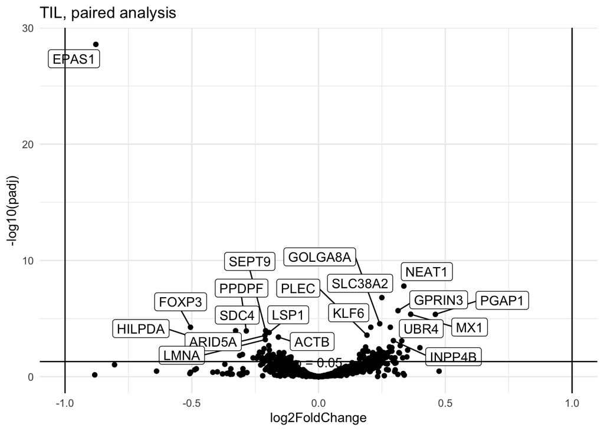

```r
volcano.custom(df.til.paired, topn = 20) +
  theme_minimal() +
  ggtitle("TIL, paired analysis")
```

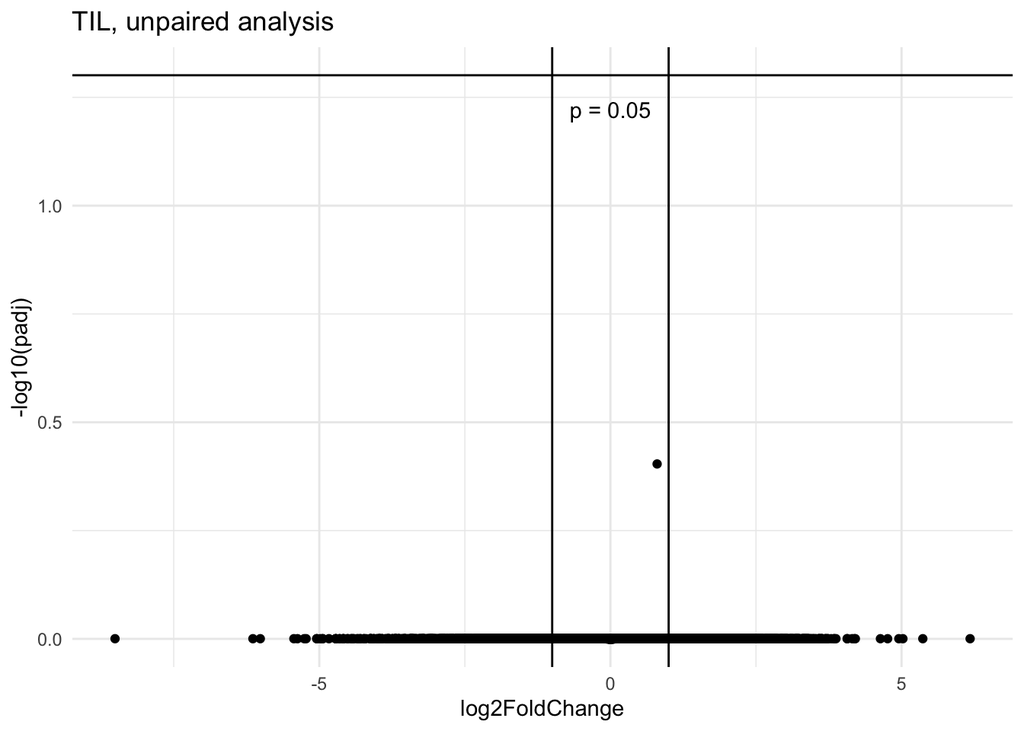

```r
volcano.custom(df.til.unpaired, topn = 20) +
  theme_minimal() +
  ggtitle("TIL, unpaired analysis")
```

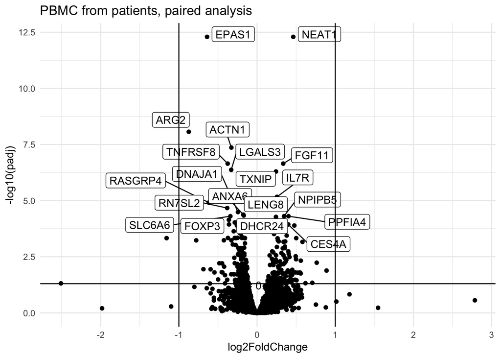

```r
volcano.custom(df.pb.paired, topn = 20) +
  theme_minimal() +
  ggtitle("PBMC from patients, paired analysis")
```

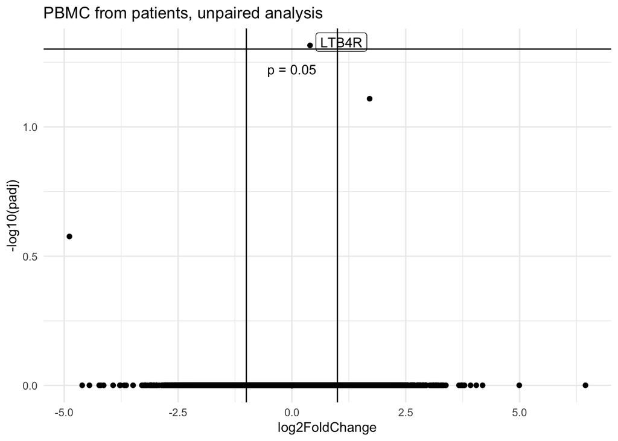

```r
volcano.custom(df.pb.unpaired, topn = 20) +
  theme_minimal() +
  ggtitle("PBMC from patients, unpaired analysis")
```

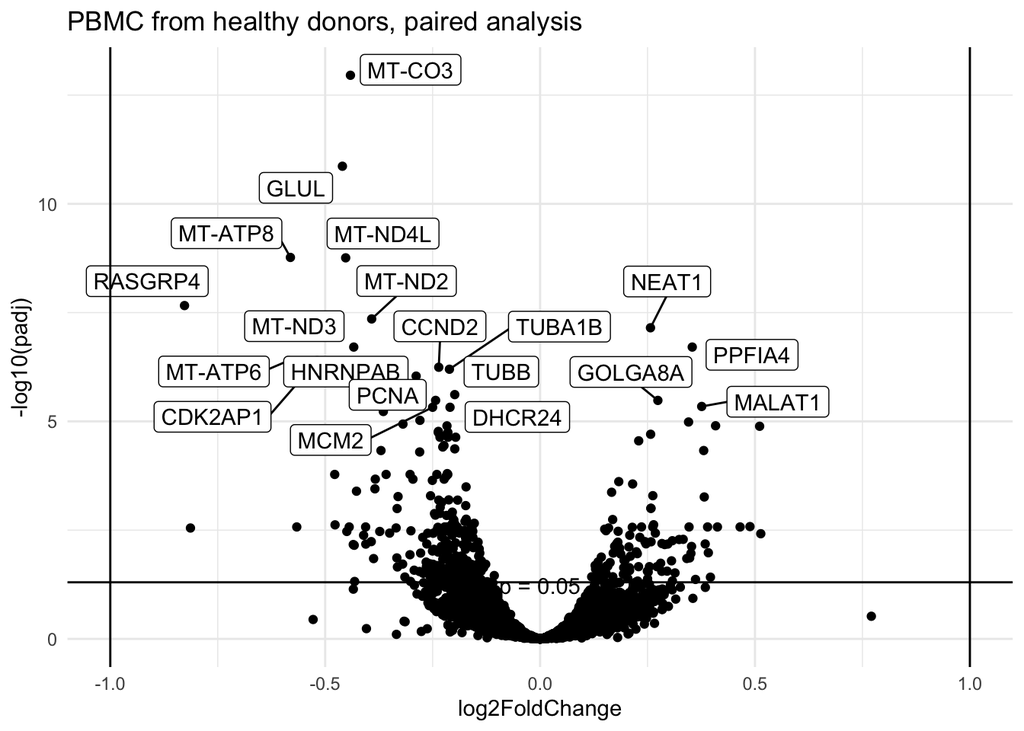

```r
volcano.custom(df.hd.paired, topn = 20) +
  theme_minimal() +
  ggtitle("PBMC from healthy donors, paired analysis")
```

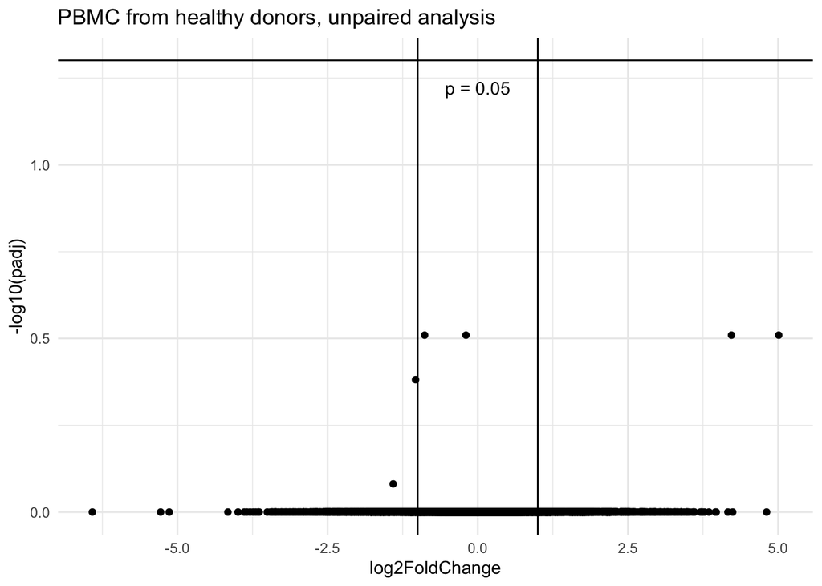

```r
volcano.custom(df.hd.unpaired, topn = 20) +
  theme_minimal() +
  ggtitle("PBMC from healthy donors, unpaired analysis")
```

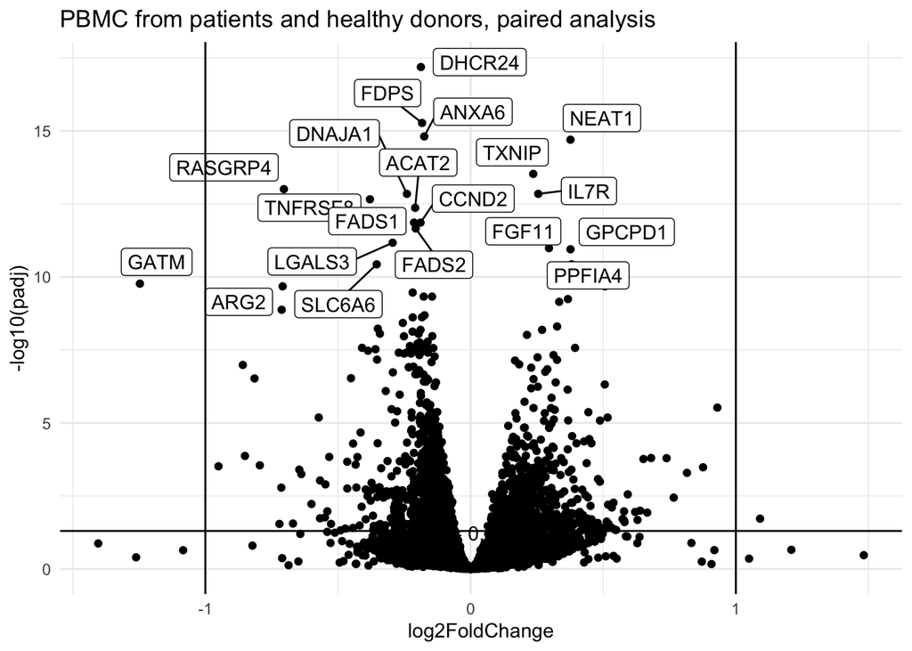

```r
volcano.custom(df.pball.paired, topn = 20) +
  theme_minimal() +
  ggtitle("PBMC from patients and healthy donors, paired analysis")
```

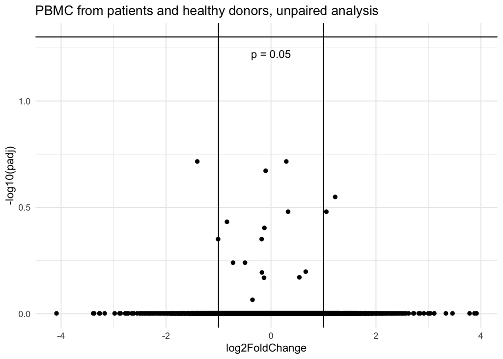

```r
volcano.custom(df.pball.unpaired, topn = 20) +
  theme_minimal() +
  ggtitle("PBMC from patients and healthy donors, unpaired analysis")
```

# Principal component analysis

Principal component analysis (PCA) was performed using a variance-stabilizing transformation (`vst`) from `DESeq2`.

The 500 most variable genes were selected based on the variance of the transformed expression values.

```r
pca.custom <- function(
  df,
  donor = c("HD", "PT"),
  organ = c("PBMC", "TIL"),
  tx = c("Bel", "DMSO")
) {

  df.comparison <- df[
    ,
    coldata$donor %in% donor &
      coldata$organ %in% organ,
    drop = FALSE
  ]

  coldata.comparison <- coldata[
    coldata$donor %in% donor &
      coldata$organ %in% organ,
    ,
    drop = FALSE
  ]

  coldata.comparison$sample <- rownames(coldata.comparison)

  dds <- DESeqDataSetFromMatrix(
    countData = round(df.comparison),
    colData = coldata.comparison,
    design = ~ id + tx
  )

  vsd <- vst(dds, blind = FALSE)

  topVarGenes <- head(
    order(
      rowVars(assay(vsd)),
      decreasing = TRUE
    ),
    500
  )

  pca <- prcomp(
    t(assay(vsd)[topVarGenes, ]),
    scale. = TRUE
  )

  pca_df <- as.data.frame(pca$x)
  pca_df$sample <- colnames(vsd)

  pca_df <- pca_df %>%
    left_join(
      coldata.comparison,
      by = "sample"
    )

  percentVar <- round(
    100 * pca$sdev^2 / sum(pca$sdev^2),
    1
  )

  pca_df$group <- paste(
    pca_df$id,
    pca_df$organ,
    sep = "_"
  )

  ggplot(
    pca_df,
    aes(
      PC1,
      PC2,
      color = tx,
      label = group
    )
  ) +
    geom_point(size = 3) +
    geom_text_repel(
      size = 3,
      max.overlaps = 30
    ) +
    xlab(
      paste0(
        "PC1 (",
        percentVar[1],
        "%)"
      )
    ) +
    ylab(
      paste0(
        "PC2 (",
        percentVar[2],
        "%)"
      )
    ) +
    theme_minimal(base_size = 14) +
    theme(
      legend.position = "right"
    )
}
```

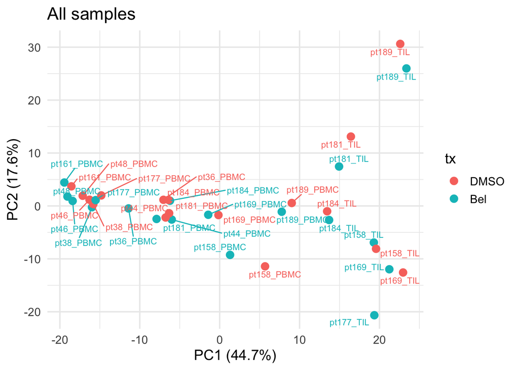

```r
pca.custom(df = df) +
  ggtitle("All samples")
```

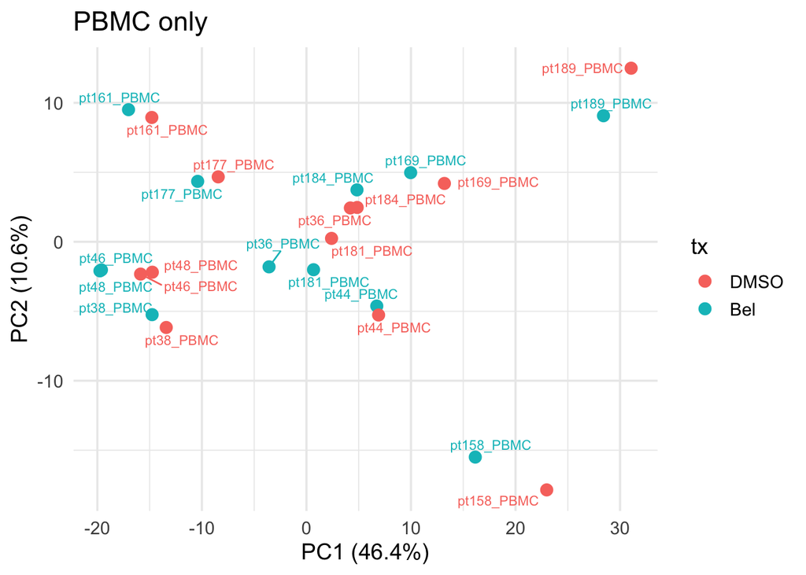

```r
pca.custom(
  df = df,
  organ = "PBMC"
) +
  ggtitle("PBMC only")
```

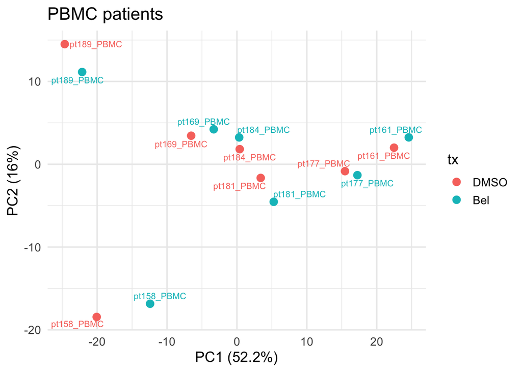

```r
pca.custom(
  df = df,
  organ = "PBMC",
  donor = "PT"
) +
  ggtitle("PBMC patients")
```

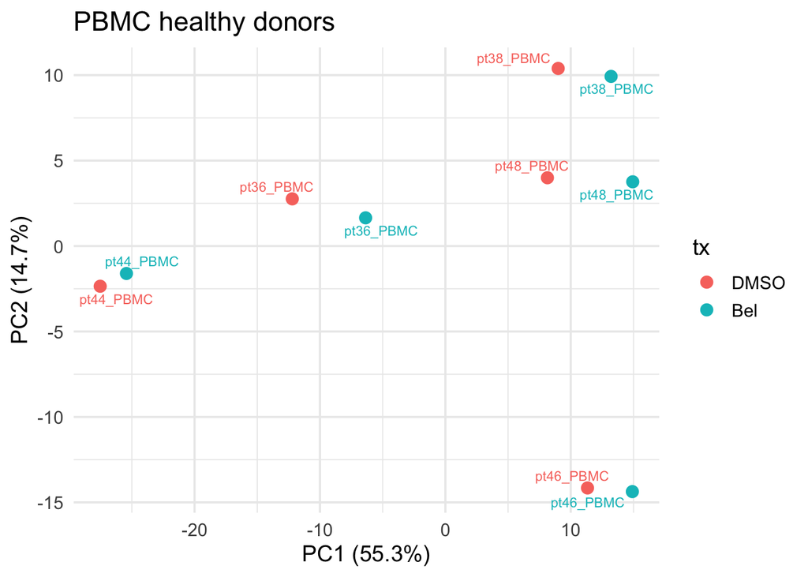

```r
pca.custom(
  df = df,
  organ = "PBMC",
  donor = "HD"
) +
  ggtitle("PBMC healthy donors")
```

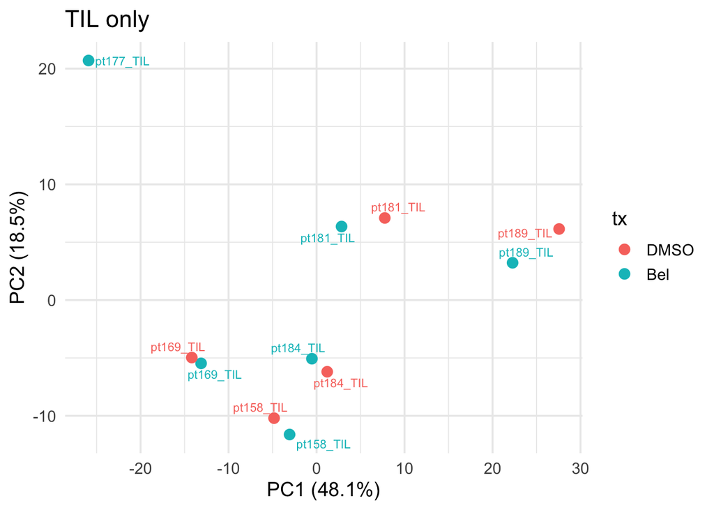

```r
pca.custom(
  df = df,
  organ = "TIL"
) +
  ggtitle("TIL only")
```

# GO and KEGG enrichment analysis

Gene Ontology (GO) and KEGG enrichment analyses were performed using `clusterProfiler`.

ENSEMBL gene identifiers were mapped to Entrez Gene identifiers using `EnsDb.Hsapiens.v86` and `org.Hs.eg.db`, as appropriate.

Upregulated and downregulated genes were analyzed separately.

For the analyses below, genes with adjusted *P* < 0.05 were used without an additional absolute log2 fold-change cutoff.

```r
gene_entrez <- AnnotationDbi::select(
  EnsDb.Hsapiens.v86,
  keys = rownames(df),
  keytype = "GENEID",
  columns = c("ENTREZID")
)

gene_entrez <- na.omit(gene_entrez)

gene_entrez <- gene_entrez[
  !duplicated(gene_entrez$GENEID),
]
```

```r
run_enrichment <- function(
  res.df,
  padj_th = 0.05,
  abslog2FC_th = 0,
  organism = "hsa"
) {

  # ENSEMBL -> ENTREZID
  if (!"ENTREZID" %in% colnames(res.df)) {
    res.df <- res.df %>%
      left_join(
        gene_entrez,
        by = c("gene" = "GENEID")
      )
  }

  # Upregulated genes
  up <- res.df %>%
    filter(
      padj < padj_th &
        log2FoldChange > abslog2FC_th
    )

  # Downregulated genes
  down <- res.df %>%
    filter(
      padj < padj_th &
        log2FoldChange < -abslog2FC_th
    )

  # Background gene universe
  universe <- as.character(
    res.df$ENTREZID
  )

  # GO and KEGG enrichment for upregulated genes
  if (length(up$baseMean) > 0) {

    go_up <- enrichGO(
      gene = up$ENTREZID,
      universe = universe,
      keyType = "ENTREZID",
      OrgDb = org.Hs.eg.db,
      ont = "ALL",
      pAdjustMethod = "BH",
      pvalueCutoff = 1,
      qvalueCutoff = 1,
      readable = TRUE
    )

    kegg_up <- enrichKEGG(
      gene = up$ENTREZID,
      universe = universe,
      organism = organism,
      pvalueCutoff = 1,
      qvalueCutoff = 1
    )
  }

  # GO and KEGG enrichment for downregulated genes
  if (length(down$baseMean) > 0) {

    go_down <- enrichGO(
      gene = down$ENTREZID,
      universe = universe,
      keyType = "ENTREZID",
      OrgDb = org.Hs.eg.db,
      ont = "ALL",
      pAdjustMethod = "BH",
      pvalueCutoff = 1,
      qvalueCutoff = 1,
      readable = TRUE
    )

    kegg_down <- enrichKEGG(
      gene = down$ENTREZID,
      universe = universe,
      organism = organism,
      pvalueCutoff = 1,
      qvalueCutoff = 1
    )
  }

  # Dotplots
  p1 <- dotplot(go_up) +
    ggtitle("GO Up")

  p2 <- dotplot(go_down) +
    ggtitle("GO Down")

  p3 <- dotplot(kegg_up) +
    ggtitle("KEGG Up")

  p4 <- dotplot(kegg_down) +
    ggtitle("KEGG Down")

  list(
    go_up_df = data.frame(go_up),
    go_down_df = data.frame(go_down),
    kegg_up_df = data.frame(kegg_up),
    kegg_down_df = data.frame(kegg_down),
    p = p1 + p2 + p3 + p4
  )
}
```

## Enrichment analyses

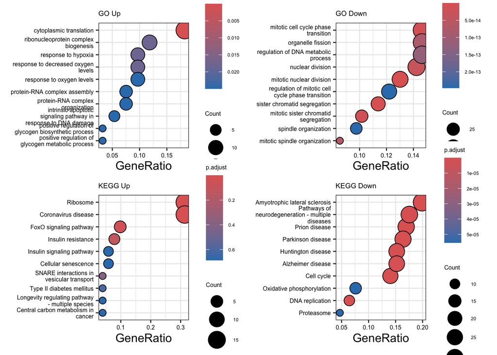

```r
enrich.hd.paired <- run_enrichment(
  res.df = df.hd.paired,
  padj_th = 0.05,
  abslog2FC_th = 0
)

enrich.hd.paired$p *
  theme(
    text = element_text(size = 6),
    axis.text.x = element_text(size = 6),
    axis.text.y = element_text(size = 6)
  )
```

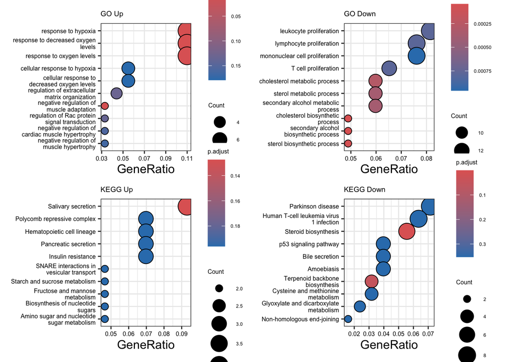

```r
enrich.pb.paired <- run_enrichment(
  res.df = df.pb.paired,
  padj_th = 0.05,
  abslog2FC_th = 0
)

enrich.pb.paired$p *
  theme(
    text = element_text(size = 6),
    axis.text.x = element_text(size = 6),
    axis.text.y = element_text(size = 6)
  )
```

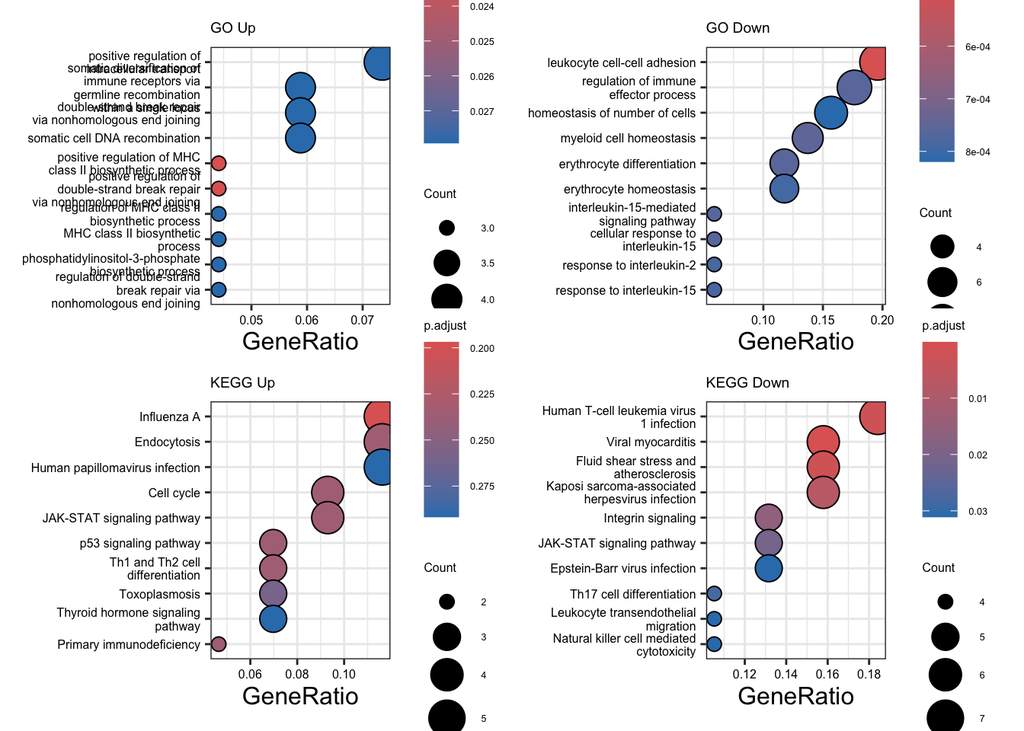

```r
enrich.til.paired <- run_enrichment(
  res.df = df.til.paired,
  padj_th = 0.05,
  abslog2FC_th = 0
)

enrich.til.paired$p *
  theme(
    text = element_text(size = 6),
    axis.text.x = element_text(size = 6),
    axis.text.y = element_text(size = 6)
  )
```

# Session information